# trump_notebook

Hello everyone, today we're going to analyze Trump's tweets ! My main questions are:

```
- What are his most popular tweets ?
- How popular its tweets became over the years ?
- Is is possible to predict a tweet's number of retweets ?
- What is the distribution of the number of retweets ?
- What are the most common words used in his tweets ?
```

First, you have to know, I decided that a popular tweet was a tweet with a lot of retweets. It may be wrong or approximative, but this is how I will analyze the data for the rest of the kernel. Let's go deep in the dataset !

```python
import pandas as pd
import numpy as np
import matplotlib.pyplot as plt
import seaborn as sn
import datetime

%pylab inline
pylab.rcParams['figure.figsize'] = (10, 7)

df = pd.read_csv("trumptweets.csv", sep=",", engine="python")
df['date'] = pd.to_datetime(df['date']) # So pandas understands it's a date

number_of_days = (df["date"].max() - df["date"].min()).days
print("Amount of tweets: {}".format(len(df)))
print("Published in {} days, which makes {:.2f} tweets per day".format(number_of_days, len(df)/number_of_days))
df.head()
```

```
Amount of tweets: 41122
Published in 3912 days, which makes 10.51 tweets per day
```

|  | id | link | content | date | retweets | favorites | mentions | hashtags | geo |
| --- | --- | --- | --- | --- | --- | --- | --- | --- | --- |
| 0 | 1698308935 | https://twitter.com/realDonaldTrump/status/169... | Be sure to tune in and watch Donald Trump on L... | 2009-05-04 20:54:25 | 500 | 868 | NaN | NaN | NaN |
| 1 | 1701461182 | https://twitter.com/realDonaldTrump/status/170... | Donald Trump will be appearing on The View tom... | 2009-05-05 03:00:10 | 33 | 273 | NaN | NaN | NaN |
| 2 | 1737479987 | https://twitter.com/realDonaldTrump/status/173... | Donald Trump reads Top Ten Financial Tips on L... | 2009-05-08 15:38:08 | 12 | 18 | NaN | NaN | NaN |
| 3 | 1741160716 | https://twitter.com/realDonaldTrump/status/174... | New Blog Post: Celebrity Apprentice Finale and... | 2009-05-08 22:40:15 | 11 | 24 | NaN | NaN | NaN |
| 4 | 1773561338 | https://twitter.com/realDonaldTrump/status/177... | "My persona will never be that of a wallflower... | 2009-05-12 16:07:28 | 1399 | 1965 | NaN | NaN | NaN |

It seems like there are a lot of NaN values here, let's check.

```python
print("Number of NaN values")
df.isna().sum()
```

```
Number of NaN values
```

```
id               0
link             0
content          0
date             0
retweets         0
favorites        0
mentions     18655
hashtags     35312
geo          41122
dtype: int64
```

We can see that geo, hashtags and mentions are filled with a lot of NaN values (especially the geo column, that have 100% of NaN values !). So let's get rid of those columns, among with the link column, that I know I won't use.

```python
df = df.drop(["geo", "hashtags", "mentions", "link"], axis=1) # Not so much to deal with
```

Let's see top 10 Trump's best tweets.

```python
max_retweets = df.sort_values("retweets", ascending=False)
content, date, retweets, favorites = 1, 2, 3, 4
place = 1

for tweet in max_retweets.values[:10]:
    print("\033[94mBest retweet {}:\033[0m \n{}\n{}\t\033[93m{} retweets\t\t{} favorites\033[0m\n".format(
        place, tweet[content], tweet[date], tweet[retweets], tweet[favorites]))
    place += 1
```

```
Best retweet 1:
# FraudNewsCNN # FNNpic.twitter.com/WYUnHjjUjg
2017-07-02 15:21:42	309892 retweets		528265 favorites

Best retweet 2:
TODAY WE MAKE AMERICA GREAT AGAIN!
2016-11-08 12:43:14	295817 retweets		518347 favorites

Best retweet 3:
Are you allowed to impeach a president for gross incompetence?
2014-06-04 12:23:11	246232 retweets		237843 favorites

Best retweet 4:
A$AP Rocky released from prison and on his way home to the United States from Sweden. It was a Rocky Week, get home ASAP A$AP!
2019-08-02 19:41:30	240363 retweets		857678 favorites

Best retweet 5:
Why would Kim Jong-un insult me by calling me "old," when I would NEVER call him "short and fat?" Oh well, I try so hard to be his friend - and maybe someday that will happen!
2017-11-12 01:48:01	229531 retweets		559317 favorites

Best retweet 6:
Be prepared, there is a small chance that our horrendous leadership could unknowingly lead us into World War III.
2013-08-31 11:46:07	222385 retweets		184454 favorites

Best retweet 7:
pic.twitter.com/11nzKwOCtU
2019-11-27 16:54:39	196687 retweets		693767 favorites

Best retweet 8:
Just spoke to @ KanyeWest about his friend A$AP Rocky’s incarceration. I will be calling the very talented Prime Minister of Sweden to see what we can do about helping A$AP Rocky. So many people would like to see this quickly resolved!
2019-07-19 22:01:47	195109 retweets		717895 favorites

Best retweet 9:
Such a beautiful and important evening! The forgotten man and woman will never be forgotten again. We will all come together as never before
2016-11-09 12:36:58	187379 retweets		564352 favorites

Best retweet 10:
pic.twitter.com/VXeKiVzpTf
2020-01-03 03:32:53	171742 retweets		812508 favorites
```

Anyway, let's look at the tweets' distribution among the years. Let's keep in mind that my dataset has been taken in January 2020.

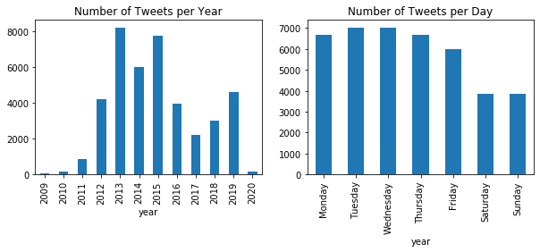

```python
plt.subplot(2, 2, 1)
plt.title("Number of Tweets per Year")
df["date"].groupby(df["date"].dt.year).count().plot(kind="bar")
plt.xlabel("year")

plt.subplot(2, 2, 2)
plt.title("Number of Tweets per Day")
tweet_cpt = df["date"].groupby(df["date"].dt.day_name()).count()
tweet_cpt.reindex(["Monday", "Tuesday", "Wednesday", "Thursday", "Friday", "Saturday", "Sunday"]).plot(kind="bar")
plt.xlabel("year")
plt.show()
```

In his best shape, Mister Trump posted ~8000 tweets ! That makes more than 22 tweets a day !

Ok so after some reflexion, I decided to analyze his tweets only since a particular date. Since his campaign for running president was in 2015, I thought about comparing his stats before and after 2015. I also want to see the stats since 2013 (when he really started to post a lot of tweets), and since 2017, because I want to look at the fresh data. When looking at the histogram, retweets' distribution are really not doing us a favour. So I use a logarithmic scale to have a better look at the distribution.

```python
after_campaign = df[df["date"] >= np.datetime64("2015-01-01")]
before_campaign = df[df["date"] < np.datetime64("2015-01-01")]
after_2013 = df[df["date"] >= np.datetime64("2013-01-01")]
past_years = df[df["date"] >= np.datetime64("2017-01-01")]
```

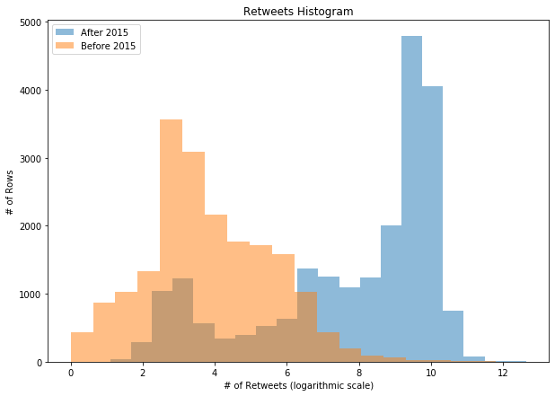

```python
X1 = np.log(after_campaign["retweets"]+1) # +1 to ensure values != 0
X2 = np.log(before_campaign["retweets"]+1)
plt.hist(X1, bins=20, alpha=0.5, label="After 2015")
plt.hist(X2, bins=20, alpha=0.5, label="Before 2015")

plt.title("Retweets Histogram")
plt.xlabel("# of Retweets (logarithmic scale)")
plt.ylabel("# of Rows")
plt.legend(loc='upper left')
plt.show()
```

```python
after_2013["retweets"].describe()
```

```
count     35863.000000
mean       6187.267546
std       10572.054143
min           0.000000
25%          23.000000
50%         505.000000
75%       10975.500000
max      309892.000000
Name: retweets, dtype: float64
```

```python
after_campaign["retweets"].describe() # 2015 and +
```

```
count     21669.000000
mean      10031.408233
std       11766.048558
min           2.000000
25%         641.000000
50%        7390.000000
75%       16353.000000
max      309892.000000
Name: retweets, dtype: float64
```

```python
past_years["retweets"].describe() # 2017 and +
```

```
count      9999.000000
mean      18665.410241
std       10938.672528
min         560.000000
25%       12512.000000
50%       16701.000000
75%       22150.500000
max      309892.000000
Name: retweets, dtype: float64
```

Okay ! So as expected, standard deviation is huge. And when looking at the median number of retweets, we can see the number has grown a lot along the years. It not surprising since he became president and more and more controversial, but still. So, to decide which part of the data we're going to analyze, I thought about plotting the median number of retweets, years by years. Indeed, I feel like since his position has changed over the years, the "retweeting potential" has also changed. If we want to predict the number of retweets, we'll have to select the time where tweets have the same "retweeting potential".

```
[]
```

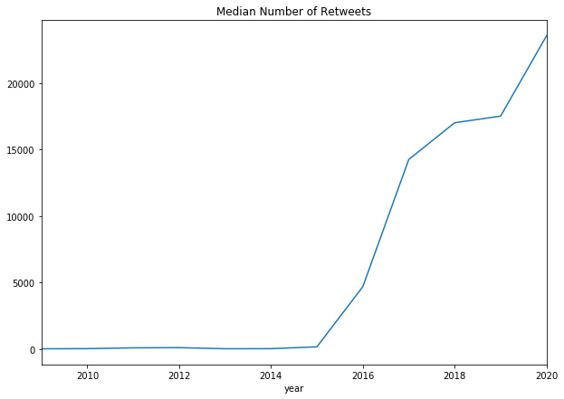

```python
df["retweets"].groupby(df["date"].dt.year).median().plot()
plt.title("Median Number of Retweets")
plt.xlabel("year")
plt.plot()
```

So, it seems that after 2017, tweets can unified under the same "potential" (I honestly don't know what I am doing right now). I will now use the "past_years" dataframe. Let's have a look at how much there is deviation between the dataset.

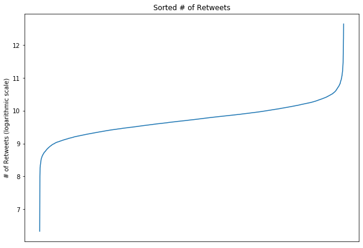

```python
plt.plot(range(0, len(past_years["retweets"])), sorted(np.log(past_years["retweets"])))
plt.title("Sorted # of Retweets")
plt.ylabel("# of Retweets (logarithmic scale)")
frame = plt.gca()
frame.axes.get_xaxis().set_visible(False)
plt.show()
```

Ok so, we have here a regression objective, to make a prediction, I use a CountVectorizer that select words, and transforms the content of a tweet into a matrix saying if each selected words appears.

```python
from sklearn.feature_extraction.text import CountVectorizer
from sklearn.linear_model import LinearRegression

train = past_years.sample(frac=0.8,random_state=200)
test = past_years.drop(train.index)
y_train = train["retweets"]
y_test = test["retweets"]
```

```python
def draw_predicted(model, X_test, y_test):
    """
    Draw the model's prediction, and superpose it with the
    expected values.
    """
    predicts = model.predict(X_test)
    df = pd.DataFrame({"predicted":predicts, "actual":y_test})
    df = df.sort_values("actual")
    plt.plot(range(0, len(df)), df["actual"], label="Actual", color='r', ls='dotted')
    plt.plot(range(0, len(df)), df["predicted"], label="Predicted", color='b', ls='dotted', alpha=0.3)
    plt.title("Model evaluation")
    plt.ylabel("# of Retweets")
    plt.legend(loc='upper left')
    frame = plt.gca()
    frame.axes.get_xaxis().set_visible(False)
    plt.show()
```

```
Score: -0.13
```

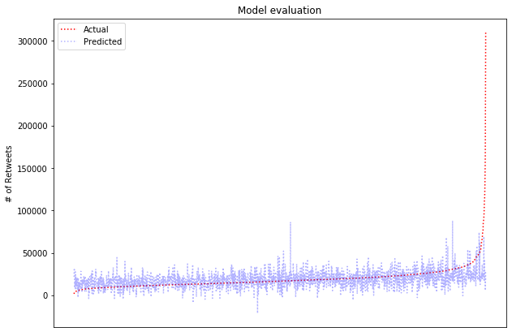

```python
vect = CountVectorizer(min_df=5, stop_words="english")
X_train = vect.fit_transform(train["content"])
X_test = vect.transform(test["content"])

model = LinearRegression()
model.fit(X_train, y_train)
print("Score: {:.2f}".format(model.score(X_test, y_test)))
draw_predicted(model, X_test, y_test)
```

Predictions are not really good (and I'm not gonna lie, it's not going to stop). I fear that the fact that some tweets are so special, with too much retweets, or not enought, the model has real issues learning. For the rest of the kernel, we're going to keep only the tweets that have a logarithmic value between 8 and 11 (we need to keep some deviation so there is something to predict).

For the rest of the predictions, we're going to use LinearRegression, DecisionTreeRegressor and RandomForestRegressor.

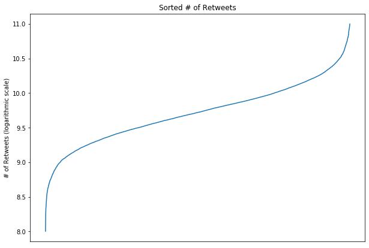

```python
common_tweets = past_years[8 < np.log(past_years["retweets"])]
common_tweets = common_tweets[np.log(common_tweets["retweets"]) < 11]

plt.plot(range(0, len(common_tweets["retweets"])), sorted(np.log(common_tweets["retweets"])))
plt.title("Sorted # of Retweets")
plt.ylabel("# of Retweets (logarithmic scale)")
frame = plt.gca()
frame.axes.get_xaxis().set_visible(False)
plt.show()

train = common_tweets.sample(frac=0.8,random_state=200)
test = common_tweets.drop(train.index)
y_train = train["retweets"]
y_test = test["retweets"]
```

```python
vect = CountVectorizer(min_df=5, stop_words="english")
X_train = vect.fit_transform(train["content"])
X_test = vect.transform(test["content"])

model = LinearRegression()
model.fit(X_train, y_train)
print("Score: {:.2f}".format(model.score(X_test, y_test)))
draw_predicted(model, X_test, y_test)
```

[output not shown]

```
Score: -0.22
```

Trying with trees

```python
from sklearn.tree import DecisionTreeRegressor

vect = CountVectorizer(min_df=5, stop_words="english")
X_train = vect.fit_transform(train["content"])
X_test = vect.transform(test["content"])

tree = DecisionTreeRegressor(max_depth=5, random_state=180)
tree.fit(X_train, y_train)
print("Score: {:.2f}".format(tree.score(X_test, y_test)))
draw_predicted(model, X_test, y_test)
```

[output not shown]

```
Score: 0.08
```

```python
from sklearn.ensemble import RandomForestRegressor

vect = CountVectorizer(min_df=5, stop_words="english")
X_train = vect.fit_transform(train["content"])
X_test = vect.transform(test["content"])

tree = RandomForestRegressor(n_estimators=10, max_depth=100, random_state=180)
tree.fit(X_train, y_train)
print("Score: {:.2f}".format(tree.score(X_test, y_test)))
draw_predicted(model, X_test, y_test)
```

[output not shown]

```
Score: 0.11
```

Ok well, it is with a big disappointment that I tell you, we did not make it. Predicting number of tweets is too hard for us (me at least). I guess thre are no particular words that makes a tweet more "retweetable" than others (but the context and the sementics must help I imagine, that's not completly random).

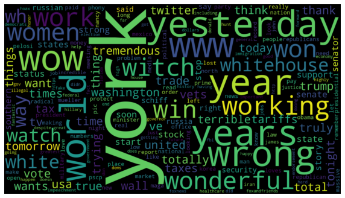

```python
from wordcloud import WordCloud

vect = CountVectorizer(min_df=100, stop_words="english")
vect.fit(past_years["content"])
wc = WordCloud(width=1920, height=1080).generate_from_frequencies(vect.vocabulary_)
plt.imshow(wc, interpolation="bilinear")
plt.axis("off")
plt.show()
```

Well that's all for me ! I hope you enjoyed the trip ! Have a good day, and take care of yourself :).